[figure not shown]

PROGRAM STUDI S2 STATISTIKA TERAPAN  
FMIPA UNIVERSITAS PADJADJARAN Panduan Akademik - Edisi 2026 · Disahkan Januari 2026

Outcome-Based Education

# Panduan Penerapan Kurikulum OBE Berbasis Proyek dan Kecerdasan Artifisial

Strategi praktis untuk menyelaraskan CPL, CPMK, Project-Based Learning, asesmen autentik, data nyata, dan responsible AI dalam pembelajaran Statistika Terapan.

AI bukan pengganti proses berpikir mahasiswa. AI digunakan sebagai alat bantu untuk meningkatkan kualitas pembelajaran, efisiensi, kemampuan verifikasi, kreativitas, dan kompetensi profesional.

**Program Studi S2 Statistika Terapan**  
Fakultas Matematika dan Ilmu Pengetahuan AlamUniversitas Padjadjaran  
2026

Dokumen Program Studi

# Identitas Dokumen dan Tim Penyusun

| Judul | Panduan Penerapan Kurikulum OBE Berbasis Proyek dan Kecerdasan Artifisial |
| --- | --- |
| Institusi | Program Studi S2 Statistika Terapan, Fakultas Matematika dan Ilmu Pengetahuan Alam, Universitas Padjadjaran |
| Edisi | 2026 |
| Periode Pengesahan | Januari 2026 |
| Sasaran | Dosen, tim kurikulum, koordinator mata kuliah, pengelola program studi, tenaga kependidikan pendukung pembelajaran, dan mahasiswa. |
| Fungsi | Panduan operasional untuk merancang, melaksanakan, menilai, dan mengevaluasi pembelajaran OBE berbasis proyek dengan pemanfaatan AI yang bertanggung jawab. |

## Tim Penyusun

Pedoman ini disusun oleh Tim Penyusun Program Studi S2 Statistika Terapan FMIPA Universitas Padjadjaran:

1. **Prof. Dr. I Gede Nyoman Mindra Jaya, M.Si.**
2. **Dr. Bertho Tantular, M.Si.**
3. **Dr. Irlandia Ginanjar, M.Si.**
4. **Dr. Anindya Apriliyanti Pravitasari, M.Si.**
5. **Dr. Gumgum Darmawan, M.Si.**

**Prinsip utama:** penerapan OBE diarahkan pada keterukuran capaian pembelajaran, keselarasan CPL–CPMK–aktivitas–asesmen, pembelajaran berbasis proyek, serta pemanfaatan kecerdasan artifisial secara transparan, bertanggung jawab, dan dapat diverifikasi.

Kata Pengantar

# Kata Pengantar

Puji syukur ke hadirat Tuhan Yang Maha Esa, karena atas rahmat dan karunia-Nya **Panduan Penerapan Kurikulum Outcome-Based Education (OBE) Berbasis Proyek dan Kecerdasan Artifisial** Program Studi S2 Statistika Terapan FMIPA Universitas Padjadjaran ini dapat disusun.

Perkembangan statistika, sains data, komputasi, dan kecerdasan artifisial menuntut proses pendidikan tinggi yang tidak hanya berorientasi pada penyampaian materi, tetapi terutama pada ketercapaian kemampuan yang dapat dibuktikan melalui kinerja mahasiswa. Oleh karena itu, implementasi OBE perlu diwujudkan secara konsisten melalui keselarasan antara Capaian Pembelajaran Lulusan (CPL), Capaian Pembelajaran Mata Kuliah (CPMK), aktivitas pembelajaran, asesmen, rubrik penilaian, serta mekanisme evaluasi dan perbaikan berkelanjutan.

Panduan ini disusun sebagai acuan praktis bagi dosen dan pengelola Program Studi S2 Statistika Terapan dalam merancang dan melaksanakan pembelajaran berbasis proyek. Proyek diposisikan sebagai wahana untuk mengintegrasikan teori, kemampuan komputasi, penggunaan data nyata, komunikasi ilmiah, kolaborasi, kreativitas, serta tanggung jawab profesional. Pemanfaatan kecerdasan artifisial ditempatkan sebagai alat bantu pembelajaran dan kerja akademik yang harus digunakan secara transparan, kritis, etis, dan tetap berada di bawah kendali penalaran manusia.

Kami berharap pedoman ini membantu membangun praktik pembelajaran yang lebih terukur, autentik, relevan dengan perkembangan keilmuan dan kebutuhan profesi, serta mendukung budaya peningkatan mutu berkelanjutan di Program Studi S2 Statistika Terapan FMIPA Universitas Padjadjaran.

Akhirnya, kami menyampaikan terima kasih kepada seluruh Tim Penyusun dan semua pihak yang berkontribusi dalam pengembangan kurikulum dan pembelajaran di Program Studi S2 Statistika Terapan. Pedoman ini terbuka untuk terus disempurnakan berdasarkan hasil evaluasi implementasi, perkembangan ilmu pengetahuan, teknologi, dan kebutuhan pemangku kepentingan.

Jatinangor, Januari 2026

Ketua Program Studi S2 Statistika Terapan  
FMIPA Universitas Padjadjaran,

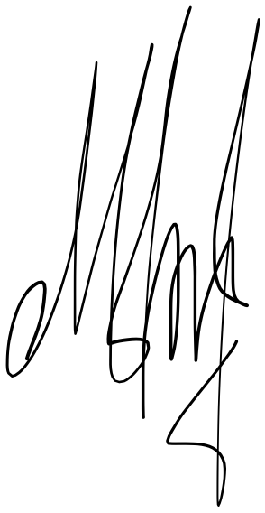

Prof. Dr. I Gede Nyoman Mindra Jaya, M.Si.

Dokumen Resmi

# Lembar Pengesahan

Panduan Penerapan Kurikulum OBE Berbasis Proyek dan Kecerdasan Artifisial

| Nama Dokumen | Panduan Penerapan Kurikulum OBE Berbasis Proyek dan Kecerdasan Artifisial |
| --- | --- |
| Unit Pengelola | Program Studi S2 Statistika Terapan, FMIPA Universitas Padjadjaran |
| Edisi | 2026 |
| Tanggal Pengesahan | Januari 2026 |
| Status | Pedoman pelaksanaan kurikulum dan pembelajaran berbasis Outcome-Based Education (OBE) |

Dokumen ini disahkan untuk digunakan sebagai pedoman dalam perencanaan, pelaksanaan, asesmen, evaluasi, dan pengembangan berkelanjutan pembelajaran pada Program Studi S2 Statistika Terapan, Fakultas Matematika dan Ilmu Pengetahuan Alam, Universitas Padjadjaran.

Disahkan di Jatinangor  
Januari 2026

Ketua Program Studi S2 Statistika Terapan  
FMIPA Universitas Padjadjaran,

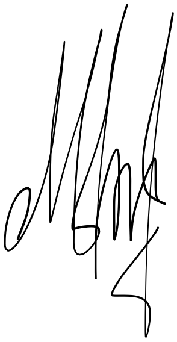

Prof. Dr. I Gede Nyoman Mindra Jaya, M.Si.

Petunjuk Dokumen

# Cara Menggunakan Buku

1. Bab 1-4 digunakan saat menyusun atau merevisi RPS dan peta keselarasan kurikulum.
2. Bab 5 menjadi pola dasar pembelajaran 16 pertemuan.
3. Bab 6-7 digunakan untuk mengatur pemanfaatan AI dan integritas akademik.
4. Bab 8-10 digunakan untuk asesmen, rubrik, monitoring, dan kontribusi individual.
5. Bab 11 menyediakan contoh proyek, sedangkan Bab 12 memuat strategi implementasi tingkat program studi.
6. Lampiran dapat disalin ke RPS, LMS, kontrak kuliah, atau logbook proyek.

Ringkasan Eksekutif

# Model Pembelajaran yang Direkomendasikan

Model paling sesuai untuk S2 Statistika Terapan adalah **satu proyek utama selama satu semester dengan pilihan terbatas (bounded choice)**, didukung tugas-tugas kecil bertahap, data nyata, asesmen individual, serta pemanfaatan AI yang transparan dan dapat diverifikasi.

1**Proyek utama**Materi kuliah mengalir menuju penyelesaian satu masalah nyata, bukan menjadi kumpulan tugas yang terpisah.

16**Pertemuan bertahap**Proyek diperkenalkan sejak awal dan berkembang melalui proposal, audit data, pemodelan, validasi, komunikasi, serta refleksi.

70%**Partisipasi dan proyek**Contoh komposisi: 70% untuk partisipasi dan ekosistem proyek, 30% untuk pengujian konseptual individual.

## Delapan Keputusan Utama

1. **Kerangka proyek diumumkan pada pertemuan pertama.** Dosen menetapkan CPMK, tema, standar data, luaran, milestone, etika, kebijakan AI, dan rubrik.
2. **Gunakan proyek utama dengan micro-deliverables.** Kedalaman tetap terjaga dan dosen dapat memberi umpan balik berkala.
3. **Terapkan constructive alignment.** Setiap aktivitas dan komponen nilai menghasilkan bukti ketercapaian CPMK.
4. **Utamakan kasus dan data nyata.** Data publik yang terdokumentasi lebih baik daripada data mitra yang belum siap atau tidak jelas hak penggunaannya.
5. **Nilai proses, bukan hanya produk akhir.** Gunakan proposal, audit data, notebook, riwayat kode, log keputusan, revisi, dan refleksi.
6. **Gunakan human verification gates untuk AI.** Keluaran AI yang memengaruhi analisis harus diperiksa, diuji, dicatat, dan dipertanggungjawabkan.
7. **Buktikan kompetensi individual.** Presentasi individual, viva, demonstrasi kode, dan analisis kasus baru mencegah free rider.
8. **Evaluasi dan perbaiki setiap semester.** Gunakan data CPMK, pengalaman mahasiswa, beban dosen, kualitas produk, dan masukan mitra.

Proyek bukan tambahan setelah teori selesai. Proyek adalah konteks yang membuat teori perlu dipelajari, diuji, dan digunakan.

Bab 1

# Fondasi Penerapan Outcome-Based Education

## 1.1 Hakikat OBE

Outcome-Based Education mengorganisasi kurikulum, pembelajaran, dan asesmen berdasarkan kemampuan yang harus dapat ditunjukkan mahasiswa pada akhir proses belajar. Titik awalnya bukan daftar materi yang ingin disampaikan dosen, melainkan performa dan bukti yang harus dapat dihasilkan mahasiswa. Karena itu, OBE menuntut kejelasan luaran, keselarasan kegiatan, asesmen berbasis bukti, dan perbaikan berkelanjutan (Spady, 1994; Biggs, 1996).

**Urutan desain OBE:** tetapkan luaran -> tentukan bukti ketercapaian -> rancang pengalaman belajar -> berikan umpan balik -> evaluasi dan perbaiki.

## 1.2 Prinsip Operasional

**Kejelasan hasil**Gunakan kata kerja terukur: merumuskan, memilih, membangun, membandingkan, memvalidasi, menginterpretasikan, mengomunikasikan, dan mempertanggungjawabkan.

**Backward design**Mulai dari bukti yang diharapkan, kemudian pilih materi dan aktivitas yang benar-benar diperlukan.

**Keselarasan**CPL, CPMK, Sub-CPMK, materi, proyek, metode pembelajaran, dan asesmen harus saling mendukung.

**Perbaikan berkelanjutan**Data asesmen digunakan untuk memperbaiki rubrik, urutan materi, beban proyek, dan dukungan pembelajaran.

## 1.3 Posisi Proyek dalam OBE

Proyek tepat digunakan ketika CPMK menuntut integrasi pengetahuan, keterampilan, dan sikap dalam situasi yang kompleks. Dalam Statistika Terapan, proyek memberi ruang untuk merumuskan masalah, memahami konteks data, memilih metode, memeriksa asumsi, menulis kode, memvalidasi model, mengomunikasikan ketidakpastian, dan mempertimbangkan konsekuensi etis.

Meta-analisis Project-Based Learning menunjukkan dampak positif pada hasil akademik, sikap, dan keterampilan berpikir. Efektivitasnya dipengaruhi oleh durasi, ukuran kelompok, jenis mata kuliah, dan desain asesmen (Zhang & Ma, 2023). Artinya, proyek harus menjadi sistem pembelajaran, bukan sekadar tugas akhir besar.

## 1.4 Penjaminan Mutu

Permendikti Saintek Nomor 39 Tahun 2025 mengatur Standar Nasional Pendidikan Tinggi, standar perguruan tinggi, sistem penjaminan mutu, akreditasi, dan pangkalan data pendidikan. Pada tingkat mata kuliah, bukti ketercapaian CPMK dan tindak lanjut perbaikan perlu disimpan secara sistematis.

**Bukti minimum:** RPS, peta CPL-CPMK, project brief, rubrik, contoh pekerjaan pada beberapa tingkat capaian, rekap nilai per CPMK, moderasi nilai, evaluasi mahasiswa, dan rencana tindak lanjut.

Bab 2

# Desain Project-Based Learning

## 2.1 Apakah Proyek Harus Ditentukan Sejak Awal?

**Ya, kerangka proyek harus dijelaskan sejak pertemuan pertama.** Namun, dosen tidak harus menentukan seluruh topik, data, metode, dan jawaban. Yang ditetapkan adalah tujuan, pertanyaan besar, batas ruang lingkup, standar bukti, milestone, etika data, kebijakan AI, dan rubrik.

Gunakan **progressive disclosure**: mahasiswa mengetahui arah dan luaran sejak awal, sementara detail metode berkembang seiring bertambahnya kompetensi.

## 2.2 Satu Proyek Utama atau Beberapa Proyek?

| Model | Kelebihan | Risiko | Kapan digunakan |
| --- | --- | --- | --- |
| Satu proyek utama | Kedalaman tinggi, integrasi materi kuat, produk autentik. | Risiko menunda pekerjaan dan kegagalan data berdampak besar. | Mata kuliah menengah-lanjut. |
| Beberapa proyek kecil | Latihan berulang dan umpan balik cepat. | Analisis cenderung dangkal dan beban administrasi tinggi. | Mata kuliah dasar atau teknik spesifik. |
| Proyek utama + tugas kecil bertahap | Menggabungkan kedalaman dan kontrol proses. | Memerlukan milestone serta rubrik yang disiplin. | **Pilihan utama untuk S2 Statistika Terapan.** |

## 2.3 Perbandingan Tiga Pendekatan

| Aspek | Dosen menentukan semuanya | Tema dosen, pilihan mahasiswa | Masalah nyata mitra |
| --- | --- | --- | --- |
| Kesesuaian CPMK | Sangat mudah dikendalikan | Tinggi dengan approval gate | Perlu negosiasi dengan kebutuhan mitra |
| Otonomi mahasiswa | Rendah | Tinggi namun terkendali | Tinggi dan autentik |
| Ketersediaan data | Mudah | Perlu audit awal | Sering tidak pasti atau terlambat |
| Beban dosen | Relatif rendah | Sedang | Tinggi |
| Risiko privasi | Rendah | Sedang | Tinggi bila data sensitif |
| Kesiapan | Pemula | **Mayoritas mata kuliah S2** | Kelas lanjut/capstone |

## 2.4 Rekomendasi Bounded Choice

Dosen menetapkan lima hal yang tidak dapat dinegosiasikan: CPMK, standar kualitas data, kedalaman metodologis minimum, bentuk bukti individual, dan aturan etika/AI. Mahasiswa memilih konteks masalah, sumber data, alternatif metode, visualisasi, dan format produk akhir.

Semakin awal posisi mata kuliah dalam kurikulum, semakin terstruktur proyeknya. Semakin lanjut kompetensi mahasiswa, semakin luas ruang pilihan dan keterlibatan mitra.

Bab 3

# Arsitektur Proyek Satu Semester

## 3.1 Isi Project Brief

1. Judul, konteks, dan alasan pentingnya masalah.
2. Driving question yang terbuka dan menuntut analisis.
3. CPMK serta bukti yang harus tampak.
4. Sumber data, metadata, lisensi, kualitas, dan kerahasiaan.
5. Luaran: laporan, notebook, kode, dashboard, artikel, policy brief, atau presentasi.
6. Milestone: proposal, audit data, rencana metode, prototipe, hasil, dan diseminasi.
7. Kebijakan AI: diizinkan, wajib deklarasi, dibatasi, atau dilarang.
8. Rubrik, mekanisme umpan balik, dan bukti individual.

## 3.2 Tahapan Pelaksanaan

**1. Orientasi**  
CPMK, masalah, tim, aturan

**2. Proposal**  
Pertanyaan, data, rencana

**3. Audit Data**  
Kualitas, etika, kelayakan

**4. Analisis**  
Model, diagnostik, revisi

**5. Diseminasi**  
Produk, viva, refleksi

## 3.3 Standar Data

- Data terkait langsung dengan pertanyaan substantif.
- Metadata dan definisi variabel cukup untuk interpretasi.
- Struktur dan ukuran data mendukung metode.
- Lisensi serta batas penggunaan jelas.
- Data pribadi dan rahasia dilindungi.
- Tersedia data cadangan bila sumber utama tidak layak.

## 3.4 Peran Dosen dan Mahasiswa

| Tahap | Peran dosen | Peran mahasiswa |
| --- | --- | --- |
| Awal | Menetapkan batas proyek, CPMK, rubrik, contoh mutu, aturan AI dan etika. | Memilih konteks, membentuk tim, mengajukan pertanyaan dan data. |
| Proses | Mini-lecture, klinik, feedback, dan keputusan approval gate. | Menguji alternatif, membuat bukti, mendokumentasikan keputusan dan revisi. |
| Akhir | Moderasi nilai, viva, evaluasi mutu, dan tindak lanjut. | Menyerahkan produk reproducible, mempresentasikan, mempertanggungjawabkan, dan merefleksikan. |

Bab 4

# Keselarasan CPL, CPMK, Aktivitas, dan Asesmen

Constructive alignment tercapai ketika aktivitas belajar mendorong mahasiswa melakukan performa yang tertulis dalam CPMK, dan asesmen mengukur performa yang sama (Biggs, 1996). Bila CPMK menuntut “memilih dan mempertanggungjawabkan model”, penilaian tidak cukup hanya meminta definisi atau menjalankan kode yang sudah tersedia.

## 4.1 Contoh Pemetaan

| CPMK | Sub-CPMK | Aktivitas | Bukti proyek | Asesmen |
| --- | --- | --- | --- | --- |
| Merumuskan masalah statistika | Menentukan tujuan keputusan, unit analisis, respons, prediktor, dan populasi | Bedah kasus dan stakeholder mapping | Problem statement | Rubrik proposal + mini-viva |
| Menilai kualitas data | Mendeteksi missingness, bias, inkonsistensi, dan risiko privasi | Data audit workshop | Audit report dan data dictionary | Checklist + demo kode |
| Memilih metode | Membandingkan metode berdasarkan tujuan, asumsi, dan struktur data | Lab dan model clinic | Analysis plan dan decision memo | Rubrik metodologi |
| Memvalidasi hasil | Diagnostik, sensitivitas, dan komunikasi ketidakpastian | Peer review dan error analysis | Validation pack | Rubrik validasi + viva |
| Mengomunikasikan hasil | Menyesuaikan pesan untuk audiens teknis dan nonteknis | Dashboard/report clinic | Produk akhir | Rubrik komunikasi |
| Menggunakan AI secara bertanggung jawab | Mendeklarasikan, memverifikasi, dan mengaudit AI | AI verification lab | AI statement dan log | Rubrik responsible AI |

## 4.2 Uji Keselarasan Cepat

- Setiap CPMK memiliki bukti kinerja yang dapat diamati.
- Setiap komponen nilai terkait dengan CPMK tertentu.
- Mahasiswa mendapat latihan sebelum asesmen sumatif.
- Rubrik menjelaskan kualitas performa, bukan hanya kelengkapan.
- Rubrik dan contoh mutu tersedia sejak awal.
- Penggunaan AI dinilai melalui verifikasi dan bukti proses.

Bab 5

# Contoh Desain Pembelajaran 16 Pertemuan

Satu proyek utama menjadi tulang punggung. Setiap pertemuan menghasilkan micro-deliverable yang terhubung dengan produk akhir.

| M | Fokus/Sub-CPMK | Aktivitas | Milestone | Peran AI | Bukti |
| --- | --- | --- | --- | --- | --- |
| 1 | Orientasi CPMK, proyek, rubrik, etika | Bedah contoh proyek dan pembentukan tim | Team charter | Demo peluang/risiko; baseline tanpa AI | Diagnostic quiz |
| 2 | Problem framing | Stakeholder mapping dan kritik pertanyaan | Concept note | Brainstorming, wajib kritik | One-page brief |
| 3 | Sumber dan kelayakan data | Lisensi, metadata, privasi | Data utama/cadangan | Pencarian awal, sumber asli wajib diperiksa | Data memo |
| 4 | Proposal analisis | Proposal clinic dan peer feedback | Gate 1 | Penyuntingan bahasa boleh | Proposal + viva |
| 5 | Audit kualitas data | Missing, duplikasi, outlier, provenance | Data audit | Coding assistant + unit check | Audit report |
| 6 | EDA dan visualisasi | Visual integrity dan uncertainty | EDA narrative | AI sebagai critic | Notebook EDA |
| 7 | Strategi analisis | Membandingkan metode/asumsi | Gate 2 | AI memberi alternatif, bukan keputusan | Decision memo |
| 8 | Evaluasi tengah | Ujian individual + progress review | Revisi ruang lingkup | Tidak boleh pada ujian tertutup | UTS |
| 9 | Implementasi model | Lab pemodelan dan debugging | Model awal reproducible | Wajib deklarasi | Code review |
| 10 | Diagnostik dan validasi | Assumption checks dan sensitivity | Validation pack | Checklist AI, eksekusi manusia | Diagnostic evidence |
| 11 | Perbandingan model | Robustness dan limitation | Gate 3 | AI sebagai red-team | Comparison memo |
| 12 | Interpretasi substantif | Interpretation clinic | Key findings | Draft AI wajib dianotasi | Interpretation audit |
| 13 | Produk komunikasi | Dashboard/report/policy brief | Prototype | Layout dan editing, angka diverifikasi | Prototype review |
| 14 | Peer review | Presentasi latihan dan reproducibility | Revisi final | Test cases dan consistency check | Peer feedback |
| 15 | Presentasi dan viva | Demo kepada kelas/mitra | Produk final | Tidak digunakan saat viva | Presentasi + viva |
| 16 | Refleksi dan evaluasi | Post-mortem dan evaluasi CPMK | Arsip proyek | Refleksi manfaat/keterbatasan | UAS + refleksi |

## 5.1 Tiga Approval Gates

1. **Gate 1 - Masalah dan data:** relevan, tersedia, etis, dan realistis.
2. **Gate 2 - Metode:** sesuai pertanyaan, struktur data, asumsi, dan CPMK.
3. **Gate 3 - Klaim:** hasil tervalidasi, ketidakpastian jelas, dan klaim tidak melampaui bukti.

Bab 6

# Strategi Adopsi AI dalam Proyek

## 6.1 Prinsip Human-Centred AI

AI harus memperkuat agency manusia, inklusi, keadilan, dan kualitas pembelajaran. Kerangka UNESCO menempatkan etika, pemahaman teknologi, penerapan pedagogis, kemampuan evaluasi, dan tanggung jawab sebagai kompetensi penting bagi mahasiswa dan dosen (UNESCO, 2023, 2024a, 2024b).

## 6.2 Empat Peran Produktif

**AI sebagai tutor**Penjelasan alternatif, latihan, dan umpan balik awal.

**AI sebagai coding assistant**Scaffolding, dokumentasi, debugging, dan test cases.

**AI sebagai critic/red team**Mencari asumsi tersembunyi, klaim lemah, bias, dan visualisasi menyesatkan.

**AI sebagai production assistant**Penyuntingan, prototipe dashboard, format laporan, dan bahan presentasi.

## 6.3 Peta Penggunaan dan Verifikasi

| Tahap | Penggunaan bermanfaat | Risiko | Human verification gate |
| --- | --- | --- | --- |
| Ide | Alternatif pertanyaan dan stakeholder | Masalah generik | Bukti kebutuhan dan konteks nyata |
| Literatur | Kata kunci dan ringkasan awal | Referensi palsu | Buka dan baca sumber asli |
| Rencana analisis | Alternatif metode/asumsi | Metode tidak sesuai | Decision memo statistik dan substantif |
| Kode | Scaffolding, debug, unit test | Kode salah/tidak dipahami | Code walk-through dan clean run |
| Interpretasi | Alternatif penjelasan | Overclaim dan sebab-akibat palsu | Cocokkan klaim dengan output/asumsi |
| Visualisasi | Layout dan aksesibilitas | Skala/angka keliru | Audit data, label, sumber, uncertainty |
| Laporan | Struktur dan editing | Penyamaran kontribusi | AI statement dan fact checking |
| Agentic workflow | Rangkaian tugas berulang | Aksi tak terpantau dan propagasi kesalahan | Persetujuan manusia pada tindakan eksternal dan keputusan metode |

## 6.4 Aturan Agentic AI

1. Agent tidak boleh mengirim, menghapus, mengunggah, atau mempublikasikan tanpa persetujuan eksplisit.
2. Hak akses mengikuti prinsip minimum necessary access.
3. Langkah penting dicatat dalam audit trail.
4. Keputusan metodologis dan interpretasi tidak didelegasikan penuh.
5. Mahasiswa harus mampu menghentikan, menjelaskan, dan mereproduksi workflow.

## 6.5 Aktivitas yang Harus Dipertanggungjawabkan Mahasiswa

- Menjelaskan konsep, asumsi, dan tujuan metode dengan kata-kata sendiri.
- Memilih model dan membela alasan pemilihan.
- Melakukan diagnostik dan sensitivity analysis.
- Menjawab viva serta mendemonstrasikan kode.
- Menyatakan keterbatasan dan menetapkan klaim akhir.

Bab 7

# Kebijakan AI dan Integritas Akademik

## 7.1 Model Lampu Lalu Lintas

### Hijau - Diperbolehkan

Brainstorming, latihan konsep, debugging awal, penyuntingan bahasa, dan pencarian kata kunci yang tidak menggantikan bukti kompetensi utama.

### Kuning - Wajib Deklarasi

Kode, visualisasi, ringkasan literatur, rancangan metode, interpretasi awal, dashboard, dan teks yang masuk produk akhir.

### Merah - Dilarang

Fabrikasi data, referensi palsu, menyembunyikan penggunaan AI, memasukkan data rahasia, atau memakai AI saat asesmen tertutup.

## 7.2 Klasifikasi Data

| Kelas | Contoh | Aturan |
| --- | --- | --- |
| Publik | Open government data, publikasi, data sintetis | Boleh dengan pemeriksaan lisensi dan atribusi. |
| Internal | Dokumen kerja atau data mitra nonpublik tanpa identitas langsung | Gunakan platform yang disetujui atau lakukan de-identifikasi. |
| Rahasia/personal | Identitas, rekam kesehatan, pegawai, kontrak, kredensial | Tidak boleh dimasukkan ke platform AI publik. |

## 7.3 AI Usage Statement

Setiap penggunaan AI yang memengaruhi substansi harus menyebut alat dan tanggal akses, tujuan, bagian yang dibantu, prompt penting, cara verifikasi, kesalahan yang ditemukan, perubahan manusia, dan tanggung jawab akhir.

**Pernyataan tanggung jawab:** “Kami telah memeriksa data, kode, sitasi, hasil, dan interpretasi. Kami bertanggung jawab atas ketepatan serta integritas produk akhir, termasuk bagian yang dikembangkan dengan bantuan AI.”

## 7.4 Jangan Mengandalkan AI Detector

Detektor AI tidak membuktikan pemahaman mahasiswa dan dapat salah mengklasifikasikan teks. Dugaan pelanggaran harus ditelaah melalui kombinasi versi dokumen, riwayat kode, log AI, sumber, viva, demonstrasi ulang, dan prosedur akademik yang adil. TEQSA mendorong reformasi asesmen yang menekankan assurance of learning dan bukti autentik (TEQSA, 2023, 2025).

## 7.5 Kesetaraan Akses

- Jangan mewajibkan fitur berbayar tanpa alternatif setara.
- Nilai kualitas penalaran dan verifikasi, bukan kecanggihan alat.
- Sediakan opsi non-AI untuk alasan aksesibilitas atau privasi.
- Berikan orientasi literasi AI bagi seluruh mahasiswa.

Bab 8

# Sistem Asesmen Autentik

## 8.1 Komposisi Nilai

| Komponen | Bobot | Bukti | Status |
| --- | --- | --- | --- |
| Partisipasi bermakna | 10% | Diskusi, peer feedback, kesiapan milestone | Individual |
| Proposal dan audit data | 10% | Proposal, dictionary, ethics check | Kelompok + viva |
| Milestone dan notebook | 15% | Versi kode, keputusan model, revisi | Kelompok dengan attribution |
| Produk akhir | 20% | Laporan/dashboard/notebook/artikel | Kelompok |
| Presentasi dan demo | 10% | Presentasi, aplikasi, respons pertanyaan | Kelompok + individual |
| Viva individual | 10% | Konsep, kode, model, keterbatasan, AI | Individual |
| Ujian/kuis konseptual | 20% | Kasus baru dan penalaran metode | Individual |
| Refleksi dan peer assessment | 5% | Refleksi belajar, kontribusi, penggunaan AI | Individual |
| Total | 100% | Partisipasi dan ekosistem proyek = 70% |  |

## 8.2 Prinsip Keadilan

1. Nilai kelompok tidak menjadi satu-satunya bukti kompetensi inti.
2. Minimal 40% total nilai berasal dari bukti individual langsung.
3. Kontribusi dinilai melalui log, peer assessment, demo, viva, dan bagian pekerjaan.
4. Rubrik diumumkan sebelum tugas dan digunakan untuk feedback formatif.
5. Moderasi dilakukan pada sampel pekerjaan untuk konsistensi.

## 8.3 Asesmen Autentik di Era AI

- **Viva:** mempertahankan keputusan analisis.
- **Code walk-through:** menjalankan dan memodifikasi kode.
- **Data perturbation:** menganalisis ulang data yang sedikit berubah.
- **Error diagnosis:** mengkritik hasil AI atau notebook yang mengandung kesalahan.
- **Reproducibility check:** produk dijalankan dari lingkungan bersih.
- **Client translation:** menjelaskan hasil kepada audiens nonteknis.

Bab 9

# Rubrik Penilaian

## 9.1 Rubrik Analitik Proyek

| Kriteria | 4 - Unggul | 3 - Baik | 2 - Cukup | 1 - Perlu Perbaikan |
| --- | --- | --- | --- | --- |
| Masalah dan konteks (10%) | Pertanyaan tajam, penting, terukur; pengguna jelas. | Relevan dan cukup fokus. | Terlalu luas atau hubungan keputusan lemah. | Tidak jelas/tidak layak. |
| Data dan tata kelola (15%) | Audit lengkap, provenance, etika, dan batas jelas. | Audit memadai. | Dokumentasi terbatas. | Data tidak tervalidasi/risiko diabaikan. |
| Metodologi (20%) | Selaras, alternatif dibandingkan, asumsi dijelaskan. | Tepat dengan justifikasi cukup. | Dapat digunakan, tetapi alasan lemah. | Tidak sesuai atau sekadar mengikuti software. |
| Implementasi (15%) | Kode bersih, modular, terdokumentasi, reproducible. | Dapat dijalankan dan cukup terdokumentasi. | Sulit direproduksi. | Tidak berjalan/tidak dipahami. |
| Validasi dan interpretasi (20%) | Diagnostik lengkap; uncertainty dan limitation terintegrasi. | Umumnya tepat. | Validasi terbatas/overclaim. | Tanpa validasi atau salah interpretasi. |
| Komunikasi (10%) | Jelas, akurat, sesuai audiens, visual efektif. | Baik dengan masalah kecil. | Pesan sulit diikuti. | Tidak komunikatif/keliru. |
| Responsible AI (10%) | Transparan, terverifikasi, aman, kritis, lengkap. | Dideklarasikan dan umumnya diverifikasi. | Deklarasi ada, verifikasi lemah. | Disembunyikan, tidak diverifikasi, atau melanggar. |

## 9.2 Rubrik Kontribusi Individual

| Kriteria | Indikator |
| --- | --- |
| Kepemilikan tugas | Tanggung jawab selesai tepat waktu dan bermutu. |
| Pemahaman | Dapat menjelaskan bagian sendiri dan keseluruhan proyek. |
| Kolaborasi | Memberi feedback, membantu integrasi, dan menyelesaikan konflik. |
| Dokumentasi | Kontribusi terlihat pada log, kode, catatan, atau produk. |
| Respons terhadap feedback | Merevisi dan menjelaskan alasan perubahan. |

Nilai kelompok dapat dikalikan faktor kontribusi individual dalam rentang terbatas, misalnya 0,85-1,10. Penyesuaian harus menggunakan triangulasi bukti, bukan peer rating semata.

Bab 10

# Monitoring, Umpan Balik, dan Kerja Kelompok

## 10.1 Sistem Monitoring

1. **Project charter:** tujuan, peran, komunikasi, konflik, dan standar file.
2. **Weekly stand-up:** selesai, hambatan, langkah berikutnya, kebutuhan keputusan.
3. **Dashboard milestone:** status hijau-kuning-merah untuk data, metode, kode, produk, dan etika.
4. **Feedback log:** umpan balik, keputusan menerima/menolak, dan revisi.
5. **Version control:** repositori atau folder versi yang merekam pemilik kontribusi.

## 10.2 Frekuensi Feedback

| Jenis | Frekuensi | Tujuan |
| --- | --- | --- |
| AI/otomatis | Setiap latihan atau commit penting | Kesalahan awal, style, test; bukan keputusan nilai. |
| Peer | Minimal tiga kali | Proposal, hasil sementara, prototype. |
| Dosen | Setiap approval gate | Menentukan kelayakan melanjutkan. |
| Mitra | Awal dan akhir | Validasi kebutuhan dan kegunaan. |

## 10.3 Mencegah Free Rider

- Kelompok ideal 3-5 mahasiswa.
- Peran primer dan reviewer silang.
- Rotasi presenter serta penjawab.
- Random individual questioning pada demo.
- Kontribusi teridentifikasi pada laporan dan repositori.
- Intervensi awal setelah dua checkpoint tidak seimbang.

Bab 11

# Contoh Proyek Statistika Terapan

| Tema | Pertanyaan Pemantik | Metode | Luaran |
| --- | --- | --- | --- |
| Kesehatan masyarakat | Wilayah dan kelompok mana mengalami ketimpangan layanan? | Regresi, SAE, spatial analysis | Dashboard dan policy brief |
| Epidemiologi | Faktor apa terkait variasi kejadian sepanjang ruang-waktu? | GLM/GAM, Bayesian spatiotemporal, survival | Artikel, notebook, risk map |
| Survei/statistik resmi | Bagaimana memperbaiki estimasi ketika sampel kecil/nonresponse tinggi? | Weighting, calibration, imputation, SAE | Technical report dan simulasi |
| Ekonometrika | Bagaimana kebijakan terkait outcome regional? | Panel, causal inference, spatial econometrics | Policy brief dan diagnostic pack |
| Forecasting | Model mana paling andal dan bagaimana uncertainty-nya? | ARIMA, state-space, hierarchical, ML | Forecast dashboard dan model card |
| Geospasial/kebencanaan | Bagaimana memetakan risiko dengan paparan dan uncertainty? | Point process, spatial regression, Bayesian mapping | Peta interaktif dan laporan risiko |
| Responsible ML | Apakah model akurat, stabil, adil, dan dapat dijelaskan? | CV, calibration, explainability, fairness | Model card, notebook, prototype |
| Analitik pendidikan | Intervensi apa membantu mahasiswa tanpa melanggar privasi? | Classification, survival, causal models | Early-warning prototype dan ethics note |

## 11.1 Standar Minimum

- Problem statement dan pengguna hasil jelas.
- Data dictionary, provenance, dan audit tersedia.
- Analisis reproducible.
- Pemilihan metode dan asumsi dapat dipertanggungjawabkan.
- Validasi, sensitivitas, dan keterbatasan dilaporkan.
- Produk sesuai audiens.
- AI dideklarasikan dan diverifikasi.
- Setiap mahasiswa lulus bukti individual.

Bab 12

# Implementasi pada Tingkat Program Studi

## 12.1 Portofolio Proyek Berjenjang

| Tahap | Karakter proyek | Peran dosen | Bukti individual |
| --- | --- | --- | --- |
| Fondasi | Data dan pertanyaan terstruktur; fokus teknik dan reproducibility. | Scaffolding, template, dataset tervalidasi. | Kuis, demo kode, mini-viva. |
| Menengah | Bounded choice; mahasiswa memilih konteks dan alternatif metode. | Approval gate dan konsultasi metodologis. | Decision memo, viva, kasus baru. |
| Lanjut/capstone | Masalah mitra/riset dan produk profesional. | Mentor, quality assurer, penghubung mitra. | Presentasi mitra, audit trail, defence. |

## 12.2 Peta Jalan Implementasi

1. **Bulan 1:** audit CPMK dan pilih mata kuliah pilot.
2. **Bulan 2:** susun project brief, data, rubrik, kebijakan AI, dan contoh mutu.
3. **Bulan 3:** workshop dosen dan penyiapan LMS/repositori.
4. **Bulan 4:** implementasi dengan monitoring beban dan checkpoint.
5. **Akhir semester:** evaluasi CPMK, mahasiswa, dosen, dan mitra.
6. **Semester berikutnya:** revisi dan perluasan bertahap.

## 12.3 Dukungan Program Studi

- Template project brief, rubrik, AI statement, dan peer assessment.
- Repositori data publik dan contoh proyek anonim.
- Pelatihan dosen mengenai asesmen autentik, AI literacy, privasi, dan agentic AI.
- Akses alat yang setara dan alternatif gratis.
- Klinik statistik, coding, visualisasi, dan reproducibility.
- Prosedur etika dan perjanjian data untuk mitra.

## 12.4 Indikator Keberhasilan

| Dimensi | Indikator |
| --- | --- |
| Ketercapaian | Proporsi mahasiswa mencapai CPMK dan peningkatan setelah feedback. |
| Proses | Milestone tepat waktu, revisi bermakna, audit trail, reproducibility. |
| Keadilan | Keseimbangan nilai kelompok/individual dan akses AI. |
| Responsible AI | Kelengkapan deklarasi, temuan verifikasi, insiden privasi. |
| Relevansi | Kegunaan produk, masukan mitra, kualitas komunikasi. |
| Efisiensi | Beban dosen, waktu feedback, efektivitas template. |

## 12.5 Rekomendasi Akhir

**Gunakan model hibrida:** satu proyek utama berbasis data nyata, tema dan standar mutu ditetapkan dosen, pilihan fokus dikembangkan mahasiswa, dan proyek mitra digunakan secara selektif. Semua proyek menggunakan milestone, approval gate, asesmen individual, serta kebijakan responsible AI yang eksplisit.

Model ini paling seimbang untuk ketercapaian CPMK, otonomi mahasiswa, beban dosen, ketersediaan data, integritas akademik, dan kebutuhan dunia kerja.

Lampiran

# Instrumen Siap Pakai

## A. Template Project Brief

**Nama mata kuliah:** **CPMK yang diukur:** **Tema/driving question:** **Pengguna hasil/mitra:** **Sumber dan klasifikasi data:** **Luaran wajib:** **Milestone:** **Aturan AI:** **Bukti individual:**

## B. AI Usage Statement

**Alat AI dan versi/tanggal akses:** _______________________________________

**Tujuan penggunaan:** _________________________________________________

**Bagian yang dibantu:** _______________________________________________

**Prompt penting:** ____________________________________________________

**Cara verifikasi:** ____________________________________________________

**Kesalahan yang ditemukan:** __________________________________________

**Perubahan manusia:** _________________________________________________

**Pernyataan:** Saya/kami bertanggung jawab atas data, kode, sitasi, hasil, dan interpretasi akhir.

## C. Log Penggunaan AI

| Tanggal | Alat | Tujuan | Ringkasan prompt | Digunakan? | Verifikasi/perubahan |
| --- | --- | --- | --- | --- | --- |

## D. Weekly Project Check-in

**Yang selesai:** ________________________________________________________

**Bukti/tautan:** ________________________________________________________

**Hambatan:** ___________________________________________________________

**Keputusan yang dibutuhkan:** __________________________________________

**Rencana dan penanggung jawab:** _______________________________________

**Status:** ☐ Hijau ☐ Kuning ☐ Merah

## E. Peer Assessment

| Nama | Kepemilikan | Pemahaman | Kolaborasi | Dokumentasi | Bukti |
| --- | --- | --- | --- | --- | --- |

## F. Pertanyaan Viva

1. Apa keputusan metodologis terpenting dan mengapa?
2. Asumsi apa paling rentan dan bagaimana memeriksanya?
3. Tunjukkan bagian kode yang Anda kerjakan dan jelaskan.
4. Apa yang terjadi bila data atau asumsi diubah?
5. Keluaran AI apa yang salah dan bagaimana Anda mengetahuinya?
6. Klaim apa yang tidak boleh dibuat?
7. Bagaimana Anda menjelaskan hasil kepada pengambil keputusan?

## G. Klausul AI untuk RPS

Mahasiswa dapat menggunakan AI untuk aktivitas yang dinyatakan diperbolehkan. Penggunaan AI yang memengaruhi kode, analisis, visualisasi, interpretasi, atau teks produk akhir wajib dideklarasikan dan diverifikasi. Mahasiswa bertanggung jawab atas akurasi, sitasi, keamanan data, dan integritas pekerjaan. Penggunaan AI pada asesmen individual tertutup, fabrikasi data atau referensi, penyamaran kontribusi AI, dan pengunggahan data rahasia ke platform publik dilarang.

## H. Checklist Penyerahan

- File dapat dibuka dan kode dapat dijalankan dari awal.
- Sumber data, lisensi, dan definisi variabel dicantumkan.
- Tabel/grafik sesuai data akhir.
- Diagnostik dan uncertainty dilaporkan.
- Referensi diverifikasi dari sumber asli.
- AI statement dan log lengkap.
- Data rahasia tidak terdapat pada file publik.
- Kontribusi anggota teridentifikasi.
- Semua anggota siap viva dan demonstrasi.

Referensi

# Daftar Pustaka

1. Biggs, J. (1996). Enhancing teaching through constructive alignment. *Higher Education, 32*, 347-364. https://doi.org/10.1007/BF00138871
2. Biggs, J., & Tang, C. (2011). *Teaching for quality learning at university* (4th ed.). Open University Press.
3. Boud, D., & Falchikov, N. (2006). Aligning assessment with long-term learning. *Assessment & Evaluation in Higher Education, 31*(4), 399-413. https://doi.org/10.1080/02602930600679050
4. European Commission. (2026). *Guidelines on the ethical use of artificial intelligence and data in teaching and learning*. European Education Area.
5. Kementerian Pendidikan Tinggi, Sains, dan Teknologi Republik Indonesia. (2025). *Peraturan Menteri Pendidikan Tinggi, Sains, dan Teknologi Nomor 39 Tahun 2025 tentang Penjaminan Mutu Pendidikan Tinggi*.
6. Kokotsaki, D., Menzies, V., & Wiggins, A. (2016). Project-based learning: A review of the literature. *Improving Schools, 19*(3), 267-277. https://doi.org/10.1177/1365480216659733
7. Panadero, E., & Jonsson, A. (2013). The use of scoring rubrics for formative assessment purposes revisited: A review. *Educational Research Review, 9*, 129-144. https://doi.org/10.1016/j.edurev.2013.01.002
8. Spady, W. G. (1994). *Outcome-based education: Critical issues and answers*. American Association of School Administrators. ERIC ED380910.
9. Tertiary Education Quality and Standards Agency. (2023). *Assessment reform for the age of artificial intelligence*. Australian Government.
10. Tertiary Education Quality and Standards Agency. (2025). *Enacting assessment reform in a time of artificial intelligence*. Australian Government.
11. UNESCO. (2019). *Beijing consensus on artificial intelligence and education*.
12. UNESCO. (2021). *Recommendation on the ethics of artificial intelligence*.
13. UNESCO. (2023). *Guidance for generative AI in education and research*.
14. UNESCO. (2024a). *AI competency framework for students*.
15. UNESCO. (2024b). *AI competency framework for teachers*.
16. Zhang, L., & Ma, Y. (2023). A study of the impact of project-based learning on student learning effects: A meta-analysis study. *Frontiers in Psychology, 14*, 1202728. https://doi.org/10.3389/fpsyg.2023.1202728

**Sumber identitas visual:** logo resmi Universitas Padjadjaran digunakan sesuai halaman identitas dan panduan logo resmi Unpad.

[figure not shown]

# Penutup

Kualitas OBE tidak ditentukan oleh banyaknya istilah dalam RPS, tetapi oleh konsistensi antara hasil yang dijanjikan, pengalaman belajar, bukti yang dikumpulkan, dan perbaikan yang dilakukan.

Belajar dengan AI harus menghasilkan manusia yang lebih mampu berpikir, bukan manusia yang semakin sulit menjelaskan pekerjaannya sendiri.

Program Studi S2 Statistika Terapan  
FMIPA Universitas Padjadjaran  
Edisi 2026